# COVID-19 Data Exploration

## by Ahmed Maher

## Investigation Overview

> I interested in (continent, location, date, total_cases, new_cases , total_deaths , new_deaths , total_cases_per_million , total_deaths_per_million , new_deaths_per_million , population , life_expectancy ) since they have a lower number of missing values which increase the reliability of our insights

## Dataset Overview

> This dataset includes COVID-19 cases per day and total cases and other information which may help us to find any relation between variable or What's going on across the different continent  
> [source](https://ourworldindata.org/coronavirus-source-data) has 30116 rows after removing nulls value before nulls it was(31074 rows).

> **this date from 2019-12-31 to 2020-07-18**

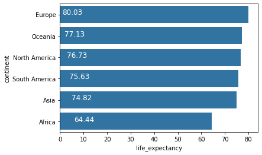

```python
# load in the dataset into a pandas dataframe
df = pd.read_csv("owid-covid-data.csv" )

interested_features = [
    "continent", "location", "date", "total_cases", "new_cases" , "total_deaths" , "new_deaths" , "total_cases_per_million"
    , "total_deaths_per_million" , "new_deaths_per_million" , "population" , "life_expectancy"
]

df = df[interested_features]

df.dropna(inplace=True)
df["date"] = pd.to_datetime(df["date"])

life_expectancy = (df.groupby(["continent"])["life_expectancy"]
                   .mean()
                   .reset_index()
                   .sort_values("life_expectancy" , ascending = False)
                  )
# color = blue
# it's a good idea to simplify the plot and reduce unnecessary distractions by plotting all bars in the same color
base_color = sb.color_palette()[0]

sb.barplot(data = life_expectancy , y="continent" , x="life_expectancy" , color=base_color);


# put a text ( life_expectancy ) on bar
locs, labels = plt.yticks()
count = 0

for loc, label in zip(locs, labels):
    plt.text(loc + 1 ,
             count,
             "{0:.2f}".format(life_expectancy.query("continent == @label.get_text()")["life_expectancy"].values[0]) ,
             color = "w"  ,
             fontsize=12)
    count +=1
```

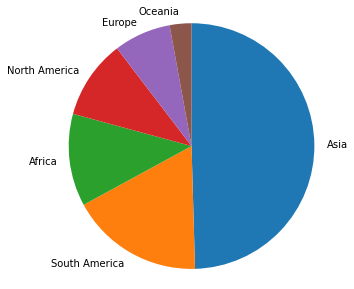

```python
population = (df.groupby(["continent"])["population"]
                   .mean()
                   .reset_index()
                   .sort_values("population" , ascending = False)
                  )
plt.figure(figsize = [10, 5])
plt.pie(x=population["population"] ,labels= population["continent"] , startangle = 90 , counterclock = False );
plt.axis('square');
```

## (Visualization 1)

> depict bar chart for life_expectancy at each country to investigate if there is a kind of relationship between this variable and death per day or other variables

> we can see that Africa has the lowest life_expectancy where Europ has the highest life_expectancy

> depict which country has the most number of population to see if there is any relation between the population of the country and their total cases however we have 6 variable here so it will be better to using bar chart but I depict pie chart for practice

> it seems Asia has 50% of the total population on the earth so I expect to see they have 40% to 50% of total cases

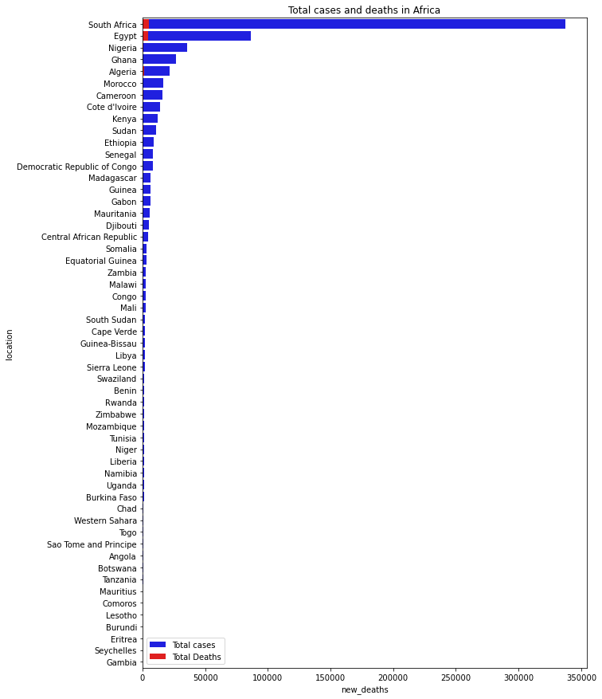

```python
summary = df.groupby(["continent" , "location"]).sum()[["new_cases", "new_deaths"]]
Africa = summary.loc["Africa"].reset_index().sort_values(["new_cases", "new_deaths"] ,ascending= [False,False])
plt.figure(figsize=[10,15])
sb.barplot(data = Africa , y="location" , x="new_cases" , color = "blue" , label="Total cases")
sb.barplot(data = Africa , y="location" , x="new_deaths" , color = "red" , label= "Total Deaths")
plt.title("Total cases and deaths in Africa")
plt.legend()
```

## (Visualization 2)

```
(0.0, 80000.0)
```

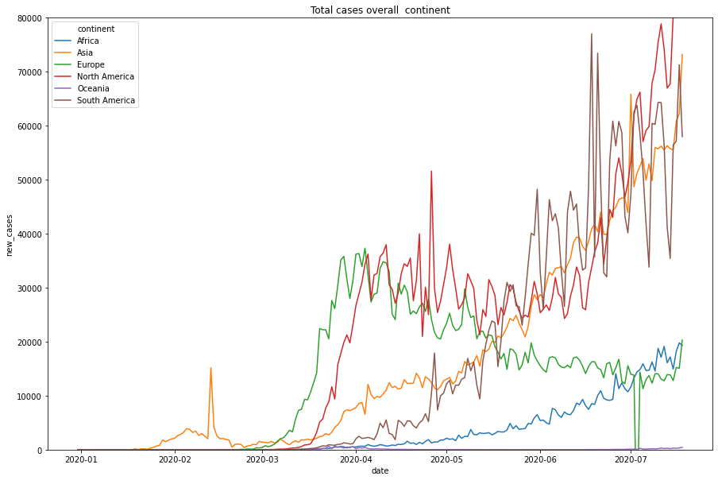

```python
summary = df.groupby(["date" , "continent"] ).sum()[["new_cases", "new_deaths" ]]
summary = summary.reset_index()
# summary
plt.figure(figsize=[15,10])
sb.lineplot(data = summary , y="new_cases" , x="date" , color = "blue" , hue="continent")
plt.title("Total cases overall  continent")
plt.ylim((0,80000))
```

```
(0.0, 5000.0)
```

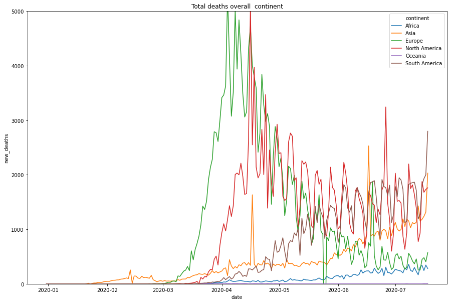

```python
plt.figure(figsize=[15,10])
sb.lineplot(data = summary , y="new_deaths" , x="date" , color = "red"  , hue= "continent")

plt.title("Total deaths overall  continent")
plt.ylim((0,5000))
```

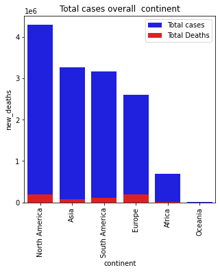

```python
Total = (summary.iloc[:,1:]
         .groupby("continent")
         .sum()
         .reset_index()
         .sort_values(["new_cases" , "new_deaths"] , ascending=[False, False] )
        )

plt.figure(figsize=[5,5])

sb.barplot(data = Total , y="new_cases" , x="continent" , color = "blue" , label="Total cases" )

sb.barplot(data = Total , y="new_deaths" , x="continent" , color = "red"  , label="Total Deaths")

plt.title("Total cases overall  continent")
plt.xticks(rotation = 90);
plt.legend()
```